# Bellabeat Case Study Report

Nathan

2023-07-27

# Step 1: Ask

## Business Task

This analysis was initiated by Urška Sršen, co-founder of Bellabeat. Sršen knows that an analysis of available data on consumers’ smart device usage would reveal opportunities for the company to grow, and has provided the following business task:

> Analyse smart device usage data to gain insight into how people are already using smart devices, then generate high-level recommendations for how these insights can inform the marketing strategy for one Bellabeat product.

## Key Stakeholders

- Urška Sršen
  - Co-founder of Bellabeat
  - Initiator of this analysis
- Bellabeat marketing team
  - Intended audience for my presentation
  - Will use my insights to guide marketing strategies

# TODO Step 2: Prepare

For this data analysis, I’ll be making use of one public data set specified by Sršen, plus additional data sets as required to address any limitations found in that dataset.

## Getting the Data

The data set specified by Sršen is the [FitBit Fitness Tracker Data Set](https://www.kaggle.com/datasets/arashnic/fitbit). This is a public data set available under the [CC0 License](https://creativecommons.org/share-your-work/public-domain/cc/) via [Kaggle user Mobius](https://www.kaggle.com/arashnic).

For the initial analysis, the data set was downloaded in its entirety from Kaggle and stored locally on my computer. This provided a baseline for analysis, with any modifications to file names, folder re-structuring, or removal of unnecessary data tables to be conducted after I’m familiar with the raw data.

## Setting up my RStudio environment

The first preparation stage involves setting up my RStudio environment for my analysis.

## Load Required Files

To get a top-level view of the data, I first load all of the required data sets directly into the my R environment. Since all of the required data tables are in CSV format, I use the readr package to iterate over all .csv files in my source data directory, loading them into the environment and naming each new data frame after its source file.

```r
csv_dir <- "Fitabase Data 4.12.16-5.12.16"
paths_dfs <- list.files(csv_dir, pattern = "*.csv", full.names = TRUE)

names_dfs <- paths_dfs %>%
  basename() %>%
  tools::file_path_sans_ext() %>%
  paste("df_", ., sep ="")

for (i in 1:length(names_dfs)) {
  assign(names_dfs[i], read_csv(paths_dfs[i]))
}
```

## Data Set Overview

The database contains data on the following features of the FitBit devices:

- Calorie burn tracking, measured in calories, summed over one-minute intervals
- Heart-rate (HR) tracking, measured in BPM, averaged over five-second intervals
- Intensity (of exercise) tracking, measured as a factor from 0 to 3, averaged over one-minute intervals
- MET tracking, measured in METs, summed over one-minute intervals
- Sleep tracking, measured as a factor from 1 to 3 (presumably quality of sleep), averaged over one-minute intervals
- Steps tracking, measured in steps, averaged over one-minute intervals
- Weight logging, measured in kg, pounds, Fat %, and BMI, sampled either by manual entry or not. It is not yet clear to me what is triggering the non-manual reports; perhaps it’s automatic logging from another device like a body composition analyser.

The raw data logged for each of these features is also included in summary tables, e.g. sleep-tracking tables that summarise nightly sleep quality based on the minute-by-minute raw data.

## Data set problems

The data set has the following issues that will need to be corrected in the Process stage:

### Inconsistent and misleading file names

The file names in the data set present the following issues:

- Unclear if data is source or summarized, e.g. “minuteCaloriesNarrow_merged.csv” is source data, while “dailyCalories_merged.csv” is summarized data
- Summarized data not always tied to specific features, e.g. “dailyActivities_merged.csv” contains data summarized from multiple features: there is no “Activity” feature with an associated source data set.
- Data shape unclear, e.g. “minuteCaloriesNarrow_merged.csv” and “dailyCalories_merged.csv” are both tall data, while “minuteIntensitiesWide_merged.csv” and “dailyIntensities_merged.csv” are both wide data
- Data sampling rate unclear, e.g. “minuteSleep_merged.csv” compared to “daySleep_merged.csv”
- Interval named before feature, affecting file sort operations, e.g. “minuteSleep_merged.csv” is sorted closer to “minuteStepsNarrow_merged.csv” than to “daySleep_merged”
- All files are suffixed with “_merged”, so no distinction is made by this information and it could be dropped

For this analysis, I’ll rename the files to use this naming convention:

- [feature]_[interval]_[src/sum]_[shape].[filetype]

| Original | Updated |
| --- | --- |
| dailyActivity_merged.csv | activity_days_sum_wide.csv |
| dailyCalories_merged.csv | calories_days_sum_tall.csv |
| dailyIntensities_merged.csv | intensity_days_sum_wide.csv |
| dailySteps_merged.csv | steps_days_sum_tall.csv |
| heartrate_seconds_merged.csv | heartrate_seconds_src_tall.csv |
| hourlyCalories_merged.csv | calories_hours_sum_tall.csv |
| hourlyIntensities_merged.csv | intensity_hours_sum_wide.csv |
| hourlySteps_merged.csv | steps_hours_sum_tall.csv |
| minuteCaloriesNarrow_merged.csv | calories_mins_src_tall.csv |
| minuteCaloriesWide_merged.csv | calories_mins_sum_wide.csv |
| minuteIntensitiesNarrow_merged.csv | intensity_mins_src_tall.csv |
| minuteIntensitiesWide_merged.csv | intensity_mins_sum_wide.csv |
| minuteMETsNarrow_merged.csv | mets_minute_src_tall.csv |
| minuteSleep_merged.csv | sleep_mins_src_tall.csv |
| minuteStepsNarrow_merged.csv | steps_mins_src_tall.csv |
| minuteStepsWide_merged.csv | intensity_mins_sum_wide.csv |
| sleepDay_merged.csv | sleep_days_sum_wide.csv |
| weightLogInfo_merged.csv | bodycomp_logs_src_wide.csv |

Notes:

- intensity_hours_sum_wide.csv: Remove “averageIntensity” column
- calories_mins_sum_wide.csv: Pivots minute-level data into one 60-column row per hour: not sure why
- intensity_mins_sum_wide.csv: Pivots minute-level data into one 60-column row per hour: not sure why
- intensity_mins_sum_wide.csv: Pivots minute-level data into one 60-column row per hour: not sure why

### TODO Inconsistent Variable Names

This issue is relatively minor, but given there’s probably a library function to correct this with minimal effort, I’m putting it on the to-do list anyway

- CapitalisedVariableNames
- snake_case_file_names
- Decontextualised variable names:
  - “value” in minuteSleep_merged should be “quality”

### Incomplete information on factor variables

This one took more work than I thought it would.

Two variables in the data set, exercise intensity and sleep quality, are numerical factors with no defined range. For these factors, I can’t tell from the data alone whether all possible values that a FitBit can record are present. The values for exercise intensity, for example, range from 0 to 3. It could be the case that the FitBits used only generate four levels of intensity, but it could just as easily be the case that the values go up to 100 (i.e. a percentage). This has clear implications for our analysis: if 3 is the max, records of 3 indicate users wear their FitBits while exercising as hard as they can, whereas if 100 is the max, records of 3 indicate users wear their FitBits while sitting on the couch as hard as they can.

With this in mind, I’m going to invest a bit of time to confirm the meaning of these variables before attempting to analyse them (read: about ten hours to investigate everything *and* learn how to do it all in R *and* learn how to make it look suitably pretty and coherent in RMarkdown)

#### Validating “Exercise Intensity” by use of R

I’ll start by determining the range of values present in the Intensity data:

```r
cat("Min Intensity:", min(df_minuteIntensitiesNarrow_merged$Intensity),
    "\nMax Intensity:", max(df_minuteIntensitiesNarrow_merged$Intensity))
```

```
## Min Intensity: 0
## Max Intensity: 3
```

The dailyActivity_merged” table provides some context clues as to what the levels might mean: the table summarises Intensity data into four new variables which, based on their names, appear to be associated with intensity levels like so:

1. Sedentary Minutes
2. Lightly Active Minutes
3. Fairly Active Minutes
4. Very Active Minutes

Let’s see if I can confirm this by recreating the data with that naming convention:

```r
# Generate my version of sleepDay_merged for comparison with the original
df_intensity_daily_sum_wide <- df_minuteIntensitiesNarrow_merged %>%
  mutate(activity_date_floored = floor_date(mdy_hms(ActivityMinute), unit = "days")) %>%
  group_by(Id, activity_date_floored) %>%
  summarize(
    minutes_sedentary      = sum(case_when(Intensity == 0 ~ 1, TRUE ~ 0)),
    minutes_lightly_active = sum(case_when(Intensity == 1 ~ 1, TRUE ~ 0)),
    minutes_fairly_active  = sum(case_when(Intensity == 2 ~ 1, TRUE ~ 0)),
    minutes_very_active    = sum(case_when(Intensity == 3 ~ 1, TRUE ~ 0))
  ) %>%
  mutate(Id_ActivityDate_UID = paste(Id, activity_date_floored, sep = "_")) %>%
  arrange(Id, activity_date_floored, Id_ActivityDate_UID)

# Compare both versions of the data and return any dates with different values
df_intensity_daily_comp <- df_dailyActivity_merged %>%
  mutate(ActivityDate_floored = floor_date(mdy(ActivityDate), unit = "days")) %>%
  mutate(Id_ActivityDate_UID = paste(Id, ActivityDate_floored, sep = "_")) %>%
  with(merge(
    .,
    df_intensity_daily_sum_wide,
    by = c("Id_ActivityDate_UID"),
    all = TRUE
    )
  ) %>%
  mutate(diff_minutes_sedentary      = minutes_sedentary      - SedentaryMinutes     ) %>%
  mutate(diff_minutes_lightly_active = minutes_lightly_active - LightlyActiveMinutes ) %>%
  mutate(diff_minutes_fairly_active  = minutes_fairly_active  - FairlyActiveMinutes  ) %>%
  mutate(diff_minutes_very_active    = minutes_very_active    - VeryActiveMinutes    ) %>%
  select(
    Id_ActivityDate_UID,
    # SedentaryMinutes,
    # minutes_sedentary,
    # LightlyActiveMinutes,
    # minutes_lightly_active,
    # FairlyActiveMinutes,
    # minutes_fairly_active,
    # VeryActiveMinutes,
    # minutes_very_active,
    diff_minutes_sedentary,
    diff_minutes_lightly_active,
    diff_minutes_fairly_active,
    diff_minutes_very_active
  ) %>%
  filter(!(diff_minutes_sedentary == 0 &
             diff_minutes_lightly_active == 0 &
             diff_minutes_fairly_active == 0 &
             diff_minutes_very_active == 0)
  ) %>%
  arrange(Id_ActivityDate_UID)

# For this table, glimpse() shows enough to demonstrate the validity of the method
glimpse(df_intensity_daily_comp)
```

```
## Rows: 465
## Columns: 5
## $ Id_ActivityDate_UID         <chr> "1503960366_2016-04-12", "1503960366_2016-…
## $ diff_minutes_sedentary      <dbl> 346, 407, 442, 400, 679, 320, 377, 364, 38…
## $ diff_minutes_lightly_active <dbl> 0, 0, 0, 0, 0, 0, 0, 0, 0, 0, 0, 0, 0, 0, …
## $ diff_minutes_fairly_active  <dbl> 0, 0, 0, 0, 0, 0, 0, 0, 0, 0, 0, 0, 0, 0, …
## $ diff_minutes_very_active    <dbl> 0, 0, 0, 0, 0, 0, 0, 0, 0, 0, 0, 0, 0, 0, …
```

The approach above appears to work perfectly, with the exception of the “sedentary minutes” calculation, which is consistently higher in my version.

That being said, I still don’t know if these are the categories FitBits work in, not another naming convention that the data authors came up with, and I don’t know if all FitBit models work this way, so let’s do something I should have done from the start: read the manuals.

#### Validating “Exercise Intensity” by Reading of Manuals

Activity trackers like FitBits detect activity intensity partly by measuring the user’s heart rate while exercising: a higher heart rate corresponds with a higher degree of exertion. As of April 2016, the three latest FitBit models with heart-rate tracking were:

- FitBit Blaze [(released January 2016)](https://www.youtube.com/watch?v=3k3DNT54NkA)
- FitBit Charge HR [(released January 2015)](https://blog.fitbit.com/charge-hr-and-surge-available-now-plus-new-charge-colors/)
- FitBit Surge [(released January 2015)](https://blog.fitbit.com/charge-hr-and-surge-available-now-plus-new-charge-colors/)

A quick look through the product manuals for each model confirms they all break down user activity into four default heart-rate zones:

| Product | HR Zone 1 | HR Zone 2 | HR Zone 3 | HR Zone 4 |
| --- | --- | --- | --- | --- |
| [FitBit Blaze](https://staticcs.fitbit.com/content/assets/help/manuals/manual_blaze_en_US.pdf) | “Out of Zone” | “Fat burn” | “Cardio” | “Peak” |
| [FitBit Charge HR](https://staticcs.fitbit.com/content/assets/help/manuals/manual_charge_hr_en_US.pdf) | “Out of Zone” | “Fat burn” | “Cardio” | “Peak” |
| [FitBit Surge](https://myhelp.fitbit.com/resource/manual_surge_en_US) | “Out of Zone” | “Fat burn” | “Cardio” | “Peak” |

While these aren’t exactly the same terms as used in the data set, they’re clearly related - “Out of Zone” equates to “Sedentary”, for example.

All three FitBit manuals also make the same claim that the default zones are “based on American Heart Association recommendations”. Even without [validating that claim](https://www.heart.org/en/healthy-living/fitness/fitness-basics/aha-recs-for-physical-activity-in-adults), it indicates to me that the reasoning behind each zone is not arbitrary, and is consistent across devices, so I think I can assume any other FitBit models circa 2016 would follow the same classification scheme.

At this point, I’m satisfied that these are the only four intensity levels I need to consider when analysing the data set, regardless of what models of FitBits were being used.

#### Validating “Sleep Quality” by Use of R *and* Reading of Manuals

As with exercise intensity, I start by determining the range of values present in the data:

```r
cat("Min Sleep:", min(df_minuteSleep_merged$value),
    "\nMax Sleep:", max(df_minuteSleep_merged$value))
```

```
## Min Sleep: 1
## Max Sleep: 3
```

The values for sleep quality range from 1 to 3. The summary data tables for sleep quality introduce only two new variable names: “Total Time In Bed”, and “Total Minutes Asleep”. There’s not a valid name for each level of factor like there was for exercise, so in this case we go straight back to the manuals:

- Blaze: tracks “both your time spent asleep and your sleep quality”
- Charge HR: tracks “the hours you sleep and your movement during the night”
- Surge: tracks “the hours you sleep and your movement during the night”

Further poking around the FitBit help pages on [how to track sleep stats](https://help.fitbit.com/articles/en_US/Help_article/1314.htm) and [what they all mean](https://help.fitbit.com/articles/en_US/Help_article/2163.htm) reveals that different devices track slightly different data if they have heart rate tracking:

- No HR tracking: Generic sleep quality tracking with “Time spent awake, restless, and asleep” categories
- HR tracking: Sleep stage tracking with “Light Sleep, Deep Sleep, and REM Sleep” stages

The help pages also single out the Charge HR and the Surge as the only HR-tracking FitBits to *not* have full sleep stage tracking, leaving the Blaze as the only device from this time period with that feature. Blaze aside, motion-based sleep quality tracking appears to go all the way back to the [FitBit One](https://myhelp.fitbit.com/s/products?language=en_US&p=one). Given this information, it seems fair to assume the following mapping for the sleep data:

- 1: Awake
- 2: Restless
- 3: Asleep

I can confirm this mapping by attempting to recreare duplicate the summary data in sleepDay_merged:

As with the intensity data, I can confirm this by recreating the data with that naming convention:

```r
# Generate my version of sleepDay_merged for comparison with the original
df_sleepDay_merged_NW <- df_minuteSleep_merged %>%
  # mutate(date_typed = mdy_hms(date)) %>%
  mutate(date_floored = floor_date(mdy_hms(date), unit = "days")) %>%
  # Sum time asleep for each Log ID
  group_by(logId) %>%
  summarize(
    "Id" = min(Id),
    # Associate each Log ID with the latest date recorded under it
    "SleepDay" = max(date_floored),
    "minutes_in_bed"   = n(),
    "minutes_awake"    = sum(case_when(value == 3 ~ 1, TRUE ~ 0)),
    "minutes_restless" = sum(case_when(value == 2 ~ 1, TRUE ~ 0)),
    "minutes_asleep"   = sum(case_when(value == 1 ~ 1, TRUE ~ 0))
  ) %>%
  # Sum time asleep for each date based on SleepDay
  group_by(Id, SleepDay) %>%
  summarize(
    "TotalSleepRecords_2" = n(),
    "TotalMinutesAsleep_2" = sum(minutes_asleep),
    "TotalTimeInBed_2" = sum(minutes_in_bed),
    "TotalMinutesAwake" = sum(minutes_awake),
    "TotalMinutesRestless" = sum(minutes_restless),
  ) %>%
  mutate("Id_SleepDay_UID" = paste(Id, SleepDay, sep = "_")) %>%
  arrange(Id_SleepDay_UID)

# Compare both versions of the data and return any dates with different values
df_sleepDay_comp <- df_sleepDay_merged %>%
  # mutate("SleepDay_typed" = mdy_hms(SleepDay)) %>%
  mutate("SleepDay_floored" = floor_date(mdy_hms(SleepDay), unit = "days")) %>%
  mutate("Id_SleepDay_UID" = paste(Id, SleepDay_floored, sep = "_")) %>%
  arrange(Id_SleepDay_UID) %>%
  with(merge(
    .,
    df_sleepDay_merged_NW,
    by = c("Id_SleepDay_UID"),
    all = TRUE
    )
  ) %>%
  mutate(recordDiff = TotalSleepRecords_2 - TotalSleepRecords) %>%
  mutate(sleepDiff = TotalMinutesAsleep_2 - TotalMinutesAsleep) %>%
  mutate(bedDiff = TotalTimeInBed_2 - TotalTimeInBed) %>%
  select(
    Id_SleepDay_UID,
    # TotalSleepRecords,
    # TotalSleepRecords_2,
    # TotalMinutesAsleep,
    # TotalMinutesAsleep_2,
    # TotalTimeInBed,
    # TotalTimeInBed_2,
    recordDiff,
    sleepDiff,
    bedDiff
  ) %>%
  filter(!(recordDiff == 0 & sleepDiff == 0 & bedDiff == 0)) %>%
  arrange(Id_SleepDay_UID)

# For this table, glimpse() shows enough to demonstrate the validity of the method
glimpse(df_sleepDay_comp)
```

```
## Rows: 16
## Columns: 4
## $ Id_SleepDay_UID <chr> "4388161847_2016-04-27", "4388161847_2016-04-30", "438…
## $ recordDiff      <dbl> 0, 0, 0, 0, 0, 0, 0, 0, 0, 0, 0, 0, 0, 0, 0, 0
## $ sleepDiff       <dbl> 22, 1, 6, 5, 1, 1, 2, 2, 520, 520, 16, 2, 10, 8, 20, 3
## $ bedDiff         <dbl> 0, 0, 0, 0, 0, 0, 0, 0, 543, 543, 0, 0, 0, 0, 0, 0
```

I was able to recreate the existing sleepDay_merged table almost perfectly by summing sleep times per Log ID, with the latest date associated with each Log ID being used as the “date” for that sleep. In practice it turns out I had the mapping inverted, and actually the following is used:

- 1: Asleep
- 2: Restless
- 3: Awake

### Duplicate data within tables

The “bodycomp_logs_src_wide.csv” file contains both kilogram and pound variables: these describe the same information, and all of the observations contain values for both variables, so one variable can be dropped with no loss of data. The choice between the two formats seems arbitrary for my analysis, so I’m choosing to keep the kilos data as its expressed in an SI unit.

## Selecting My Tools

For this analysis I wanted a tool or set of tools with the following features:

- Sufficient power enough to handle large data sets, e.g. FitBit data tables with >1M observations
- Functions for data manipulation, e.g. loading, cleaning and combining data sets
- Functions for data analysis, e.g. regression analysis and statistical analysis
- Functions for data visualisation, e.g. plotting
- Methods for storing the details of my analysis methodology separate from the data itself, e.g. separate source code files, but not macros stored within spreadsheet files
- Methods for generating reports from my analysis with as little repetition of work as possible, e.g. inline markdown languages, or Page Layout views in spreadsheet applications
- A straightforward learning process and user interface, e.g. spreadsheet tools typically have a single “Add Chart” tool under which all of their powerful charting options can be found; contrast this with learning to download, enable, and finally use the ggplot2 R library

With these requirements in mind, I considered three tools: R, spreadsheets, and databases:

| Feature | R | Spreadsheets | Databases |
| --- | --- | --- | --- |
| Power for large data sets | Yes | No | Yes |
| Data manipulation tools | Yes | Yes | Yes |
| Data analysis tools | Yes | Yes | No |
| Data visualisation tools | Yes | Yes | No |
| Separate analysis files | Yes | No | Yes |
| Streamlined report generation | Yes | No | No |
| Straightforward to learn | No | Yes | No |

Clearly, R is the best single tool for this analysis. R lacks the straightfoward operation of spreadsheet tools, and I will need to learn libraries and programming techniques as I do my analysis, but this is acceptable given my prior experience with other programming languages like Python.

Note: Python itself was not considered for this analysis: while it shares most of the features, advantages, and disadvantages of R, I’m already familiar with Python and wanted to use this case study to familiarise myself with R instead

## Cleaning the data

### Update File Names

For this analysis, I’ll rename the files to use this naming convention:

> [feature]_[interval]_[src/sum]_[shape].[filetype]

Applying the naming convention to only those files I want to keep yields the following files:

| Original | Updated |
| --- | --- |
| dailyActivity_merged.csv | activity_days_sum_wide.csv |
| dailyCalories_merged.csv | calories_days_sum_tall.csv |
| dailyIntensities_merged.csv | intensity_days_sum_wide.csv |
| dailySteps_merged.csv | steps_days_sum_tall.csv |
| heartrate_seconds_merged.csv | heartrate_seconds_src_tall.csv |
| hourlyCalories_merged.csv | calories_hours_sum_tall.csv |
| hourlyIntensities_merged.csv | intensity_hours_sum_wide.csv |
| hourlySteps_merged.csv | steps_hours_sum_tall.csv |
| minuteCaloriesNarrow_merged.csv | calories_mins_src_tall.csv |
| minuteCaloriesWide_merged.csv | calories_mins_sum_wide.csv |
| minuteIntensitiesNarrow_merged.csv | intensity_mins_src_tall.csv |
| minuteIntensitiesWide_merged.csv | intensity_mins_sum_wide.csv |
| minuteMETsNarrow_merged.csv | mets_minute_src_tall.csv |
| minuteSleep_merged.csv | sleep_mins_src_tall.csv |
| minuteStepsNarrow_merged.csv | steps_mins_src_tall.csv |
| minuteStepsWide_merged.csv | intensity_mins_sum_wide.csv |
| sleepDay_merged.csv | sleep_days_sum_wide.csv |
| weightLogInfo_merged.csv | bodycomp_logs_src_wide.csv |

# TODO: Cleaning data after load

# TODO Step 3: Clean

In which I clean the prepared data set prior to analysis

## Apply filename conventions

The new file naming convention will clearly indicate:

- Associated feature
- Source or Summary data tables
- Wide or Narrow format
- Observation sampling interval

Additional conventions:

- snake_case over camelCase

Data cleaning within the tables:

- lower_snake_case for all variable names

## Transform into tidy data frames

The Fitabase data set has the following characteristics:

- Tables encoded in different formats, including both narrow and wide
- Variables sampled at different rates, e.g. per-second and per-day
- Tables containing duplicated or summarised data from other tables.
- CapitalisedVariableNames
- snake_case_file_names
- Inconsistent file names: file names generally include the feature and polling rate, but not in the same format across files
- Duplicate data, e.g. weight logs in both kilos and pounds in the same table

Of these features, some are better understood by analysing the summarized data:

- sleepDay_merged (I don’t need intra-night sleep stats)

## Identify Raw Data Tables

The following base/narrow data tables are included in the Fitabase data set:

- heartrate_seconds_merged
- minuteCaloriesNarrow_merged
- minuteIntensitiesNarrow_merged
- minuteMETsNarrow_merged
- minuteStepsNarrow_merged
- minuteSleep_merged
- weightLogInfo_merged

These data tables contain all of the data included in the summary tables.

While the summary tables provides some useful ready-made summaries and potential for visualisation, further processing with R will benefit from isolating the unique data sets and re-organising them into tidy data. “Tidy data” means:

- One table (or data frame) per observational unit (e.g. one for sleep, one for steps, etc.)
- One variable per table column
- One observation per table row

## Clean metadata

Cleaning Functions to use: * rename_with(df, format) * clean_names(df)

TODO: * Optional: Standardise column names e.g. all ID columns named Id. I’ve checked this

## Convert invalid data types

- dates in character format (CHR) are converted to datetime (DTTM) format
- ID values, including user IDs and log IDs, are converted from double format (DBL) to CHR. This is to prevent inappropriate mathematical operations that may cause obfuscation or loss of data, e.g. scientific notation or rounding, respectively.

```r
df_minuteSleep_cleaned <- df_minuteSleep_merged %>%
  mutate(Id = as.character(Id),
         logId = as.character(logId),
         date = mdy_hms(date))
```

## Remove duplicates from sleepMinute table

Data for Id 4702921684, 5/7/2016, is duplicated.

# TODO Step 4: Analyse

In which I do my actual analysis

## Analysing function usage

### Method

This part of the analysis uses the unique IDs to determine what proportion of the sample base uses each feature:

1. For each data frame:
   1. Count number of unique IDs in data frame
   2. Add all unique IDs into id vector
2. For each data frame:
   1. Calculate unique ID number as percentage of total unique IDs
3. Generate bar-graph showing utilisation rate of each feature:
   1. Shown initially as a proportion for every data frame
   2. Summarized into proportions for one indicative data frame per feature

### Implementation

NOOOOOOOOO

I can’t just look at which features are used by 33 users, i.e. group by feature then count IDs: I also need to group by ID and count features. This allows us to investigate which users go with which dataset: are the people who don’t use MET tracking the same as the people who don’t use HR tracking, for instance

```r
#TODO: Collate databases by feature type

# Note variable names use "Id" instead of "ID" by convention for consistency with database column names
feature_df_names = c(
  "df_heartrate_seconds_merged",
  "df_minuteCaloriesNarrow_merged",
  "df_minuteIntensitiesNarrow_merged",
  "df_minuteMETsNarrow_merged",
  "df_minuteStepsNarrow_merged",
  "df_minuteSleep_merged",
  "df_weightLogInfo_merged"
)

column_names <- c("name", "Id_count")
df_unique_Id_counts <- data.frame(matrix(nrow = 0, ncol = length(column_names)))
colnames(df_unique_Id_counts) <- column_names

unique_Ids <- vector("numeric")

# Determine the number of unique Ids present in each dataframe
for (name in feature_df_names) {
  df <- get(name)
  unique_Ids_in_df <- unique(df$Id)
  unique_Ids <- unique(c(unique_Ids, unique_Ids_in_df))
  # Extract count of unique IDs for current dataframe
  df_new_row <- data.frame(name, length(unique_Ids_in_df))
  colnames(df_new_row) <- column_names
  df_unique_Id_counts <- rbind(df_unique_Id_counts, df_new_row)
}
df_unique_Id_counts$name <- reorder(df_unique_Id_counts$name, df_unique_Id_counts$Id_count, decreasing = TRUE)
```

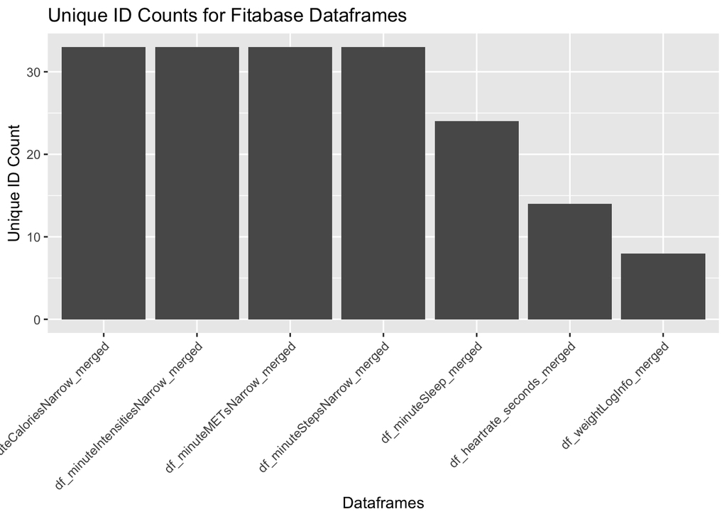

```r
ggplot(df_unique_Id_counts, aes(name, Id_count)) +
  geom_col() +
  coord_cartesian(ylim=c(0L, length(unique_Ids))) +
  theme(axis.text.x=element_text(angle=45, hjust=1)) +
  labs(x="Dataframes", y="Unique ID Count", title="Unique ID Counts for Fitabase Dataframes")
```

### Findings

The most used features were: * Calorie Tracking * Exercise Intensity Tracking * Exercise MET Tracking * Step Tracking

These features were used by all 33 participants in the database.

The least used features were: * Weight logging * Sleep logging * Heart-rate monitoring

### Note on different FitBit devices

The dataset does not indicate what type of FitBit each participant was using: it is possible the less-used features are unavailable on certain devices. This has a few potential implications:

- Those consumers who don’t use all would like to use the features on fully-featured FitBits, but other factors drive them to purchase FitBits with fewer features, e.g. cost

### MET Tracking and why Bellabeat doesn’t require it

All of the most-used features from the database are available on the Bellabeat Ivy except MET tracking. The MET (Metabolic Equivalent of Task) is a unit of measurement for energy expenditure, or exertion, intended to aid direct comparison between different types of exercise. The Ivy does not generate MET data, but does track calories burnt, which can also be used as a measure of exertion. I recommend presenting calorie tracking as a suitable alternative when targeting advertising at those customers who use the MET tracking feature.

## Analysing the most-used features

### Consumer Behaviors w.r.t. Calorie Tracking vs. MET Tracking

### Display data for first-glance analysis

# TODO Step 5: Share

In which I present all of my key findings and their supporting visualisations

# TODO Step 6: Act

In which I summarise my recommendations